# Tugas Pertemuan 1 - Smoothing

Indra Mahib Z. R

2024-08-25

## Library Used

```r
library(tidyverse)
library(ggplot2)
library(forecast)
library(graphics)
library(TTR)
library(TSA)
```

## Data Preparation

Data yang digunakan adalah data yang berasal dari DEPHUB, berupa data harian penumpang berangkat di Bandara Sultan Aji (BPN) di Kalimantan Timur. Periode data yang digunakan secara keseluruhan adalah dari 1 Januari 2023 hingga 31 Juni 2024 dengan total 571 periode. Data ini kemudian dibagi ke 5 mahasiswa yang tergabung dalam kelompok. Sehingga data yang digunakan pada tugas ini berjumlah 115 hari (periode).

### Data Loading

```r
dt <- read.csv("D:\\IPB\\5\\MPDW\\data\\dt_pt3.csv")
dt <- dt %>% select(Tanggal, Penumpang.Berangkat)
## lower case names
names(dt) <- tolower(names(dt))
head(dt)
```

```
##      tanggal penumpang.berangkat
## 1 2023-08-19                6222
## 2 2023-08-20                6758
## 3 2023-08-21                6542
## 4 2023-08-22                7400
## 5 2023-08-23                7196
## 6 2023-08-24                6663
```

```r
str(dt)
```

```
## 'data.frame':    115 obs. of  2 variables:
##  $ tanggal            : chr  "2023-08-19" "2023-08-20" "2023-08-21" "2023-08-22" ...
##  $ penumpang.berangkat: int  6222 6758 6542 7400 7196 6663 6754 6897 6753 6066 ...
```

Dapat dilihat bahwa variabel tanggal merupakan tipe data karakter, sehingga perlu diubah menjadi tipe data date.

```r
dt$tanggal <- as.Date(dt$tanggal, format = "%Y-%m-%d")
str(dt)
```

```
## 'data.frame':    115 obs. of  2 variables:
##  $ tanggal            : Date, format: "2023-08-19" "2023-08-20" ...
##  $ penumpang.berangkat: int  6222 6758 6542 7400 7196 6663 6754 6897 6753 6066 ...
```

```r
### mengubah data menjadi format time series
dt.ts <- ts(dt$penumpang.berangkat)
```

## Eksplorasi Data

### Statistik Deskriptif

```r
summary(dt.ts)
```

```
##    Min. 1st Qu.  Median    Mean 3rd Qu.    Max.
##    5450    6229    6754    6782    7300    8761
```

nilai median dan mean tidak berbeda jauh.

### Visualisasi Data

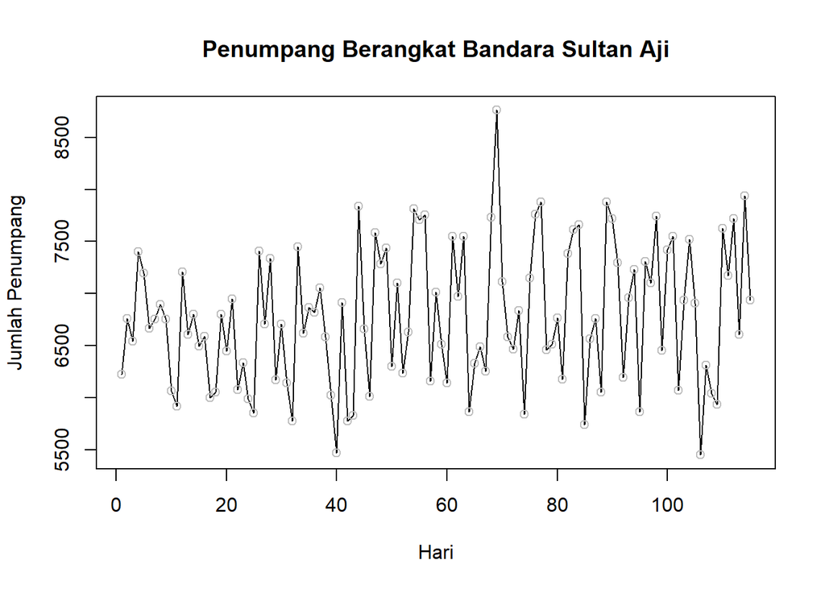

```r
plot(dt.ts, main = "Penumpang Berangkat Bandara Sultan Aji", ylab = "Jumlah Penumpang", xlab = "Hari")
points(dt.ts, col = "grey")
```

Dari plot deret waktu yang terbentuk seperti terdapat pola seasonal yang terlihat cukup jelas dan pola tren yang kecil.

## Spliting Train & Test Data

```r
train_dt <- dt[1:90,]
test_dt <- dt[91:115,]
train.ts <- ts(train_dt$penumpang.berangkat)
test.ts <- ts(test_dt$penumpang.berangkat)
```

Mari cek apakah data sudah sesuai atau belum dengan membuat plot.

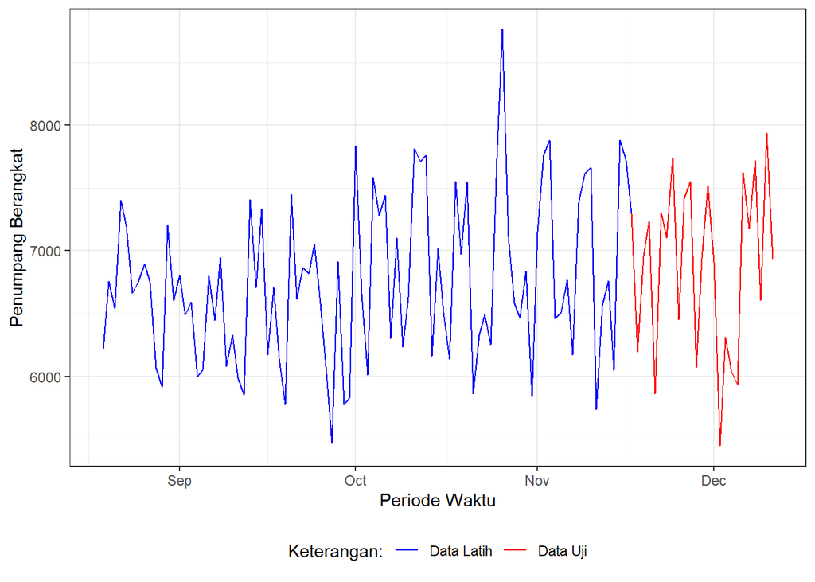

```r
ggplot() +
  geom_line(data = dt, aes(x = tanggal, y = penumpang.berangkat, col = "Data Latih")) +
  geom_line(data = test_dt, aes(x = tanggal, y = penumpang.berangkat, col = "Data Uji")) +
  labs(x = "Periode Waktu", y = "Penumpang Berangkat", color = "Legend") +
  scale_colour_manual(name="Keterangan:", breaks = c("Data Latih", "Data Uji"),
                      values = c("blue", "red")) +
  theme_bw() + theme(legend.position = "bottom",
                     plot.caption = element_text(hjust=0.5, size=12))
```

Data yang kita bagi sudah sesuai.

## Smoothing

### Single Moving Average

```r
sma3 <- SMA(train.ts, n = 3)
sma5 <- SMA(train.ts, n = 5)
```

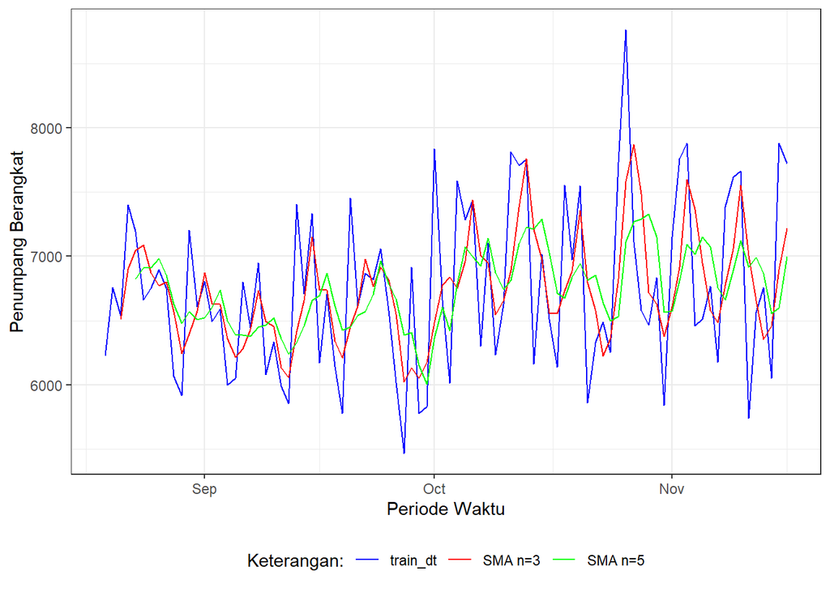

```r
## perbandingan plot awal dan SMA
ggplot()+
  geom_line(data = train_dt, aes(x = tanggal, y = penumpang.berangkat, col = "train_dt"))+
  geom_line(data = dt[1:90,], aes(x = tanggal, y = sma3, col = "SMA n=3"))+
  geom_line(data = dt[1:90,], aes(x = tanggal, y = sma5, col = "SMA n=5"))+
  labs(x = "Periode Waktu", y = "Penumpang Berangkat", color = "Legend")+
  scale_colour_manual(name="Keterangan:", breaks = c("train_dt", "SMA n=3","SMA n=5"),
                      values = c("blue", "red","green"))+
  theme_bw() + theme(legend.position = "bottom",
                     plot.caption = element_text(hjust=0.5, size=12))
```

#### Forecasting SMA

```r
## forecast 1 periode ke depan
sma3_f1 <- c(NA,sma3)
### forecast 25 period ke depan
predict <- c(sma3_f1,rep(sma3_f1[length(sma3_f1)],24))
aktual <- c(train.ts,rep(NA,25))
smoothig <- c(sma3,rep(NA,25))

sma3_forecast <- cbind(aktual,smoothig,predict)
```

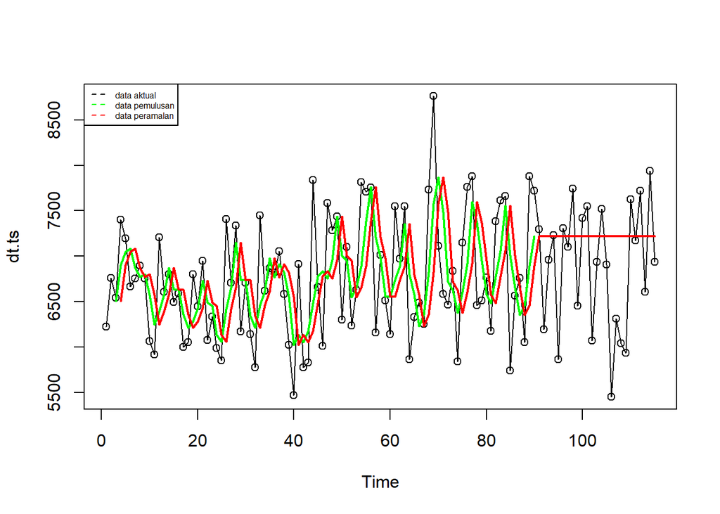

```r
## plot hasil
ts.plot(dt.ts)
points(dt.ts)
lines(sma3_forecast[,2],col="green",lwd=2)
lines(sma3_forecast[,3],col="red",lwd=2)
legend("topleft",c("data aktual","data pemulusan","data peramalan"), lty=8, col=c("black","green","red"), cex=0.5)
```

Hasil prediksi dari SMA akan menghasilkan nilai konstan di akhir prediksi, maka dari itu lebih cocok digunakan ketika data cenderung stasioner.

#### Evaluasi Model

##### Evaluasi Training

```r
### Training error

train_error_sma3 <- train.ts - predict[length(train.ts)]
RMSE_train_sma3 <- sqrt(mean(train_error_sma3^2, na.rm = T))
MAPE_train_sma3 <- mean(abs(train_error_sma3/train.ts)*100, na.rm = T)

RMSE_train_sma3
```

```
## [1] 664.3887
```

```r
MAPE_train_sma3
```

```
## [1] 8.423226
```

Nilai evaluasi pada data latih menggunakan RMSE adalah 664.3887 dan MAPE adalah 8.4%.

##### Evaluasi Testing

```r
### Testing error

test_error_sma3 <- test.ts - predict[length(train.ts):length(train.ts)+length(test.ts)]
RMSE_test_sma3 <- sqrt(mean(test_error_sma3^2, na.rm = T))
MAPE_test_sma3 <- mean(abs(test_error_sma3/test.ts)*100, na.rm = T)

RMSE_test_sma3
```

```
## [1] 746.4012
```

```r
MAPE_test_sma3
```

```
## [1] 9.088387
```

Nilai evaluasi pada data uji menggunakan RMSE adalah 746.4012 dan MAPE adalah 9.1 %. Hal ini lebih tinggi dari hasil traininig namun tidak terlalu berbeda jauh.

### Double Moving Average

#### Forecast DMA

```r
dma3 <- SMA(sma3, n = 3)
At <- 2*sma3 - dma3
Bt <- 2/(3-1) * (sma3 - dma3)
dma.res <- At + Bt
```

```r
t = 1:25
f = c()

for (i in t) {
  f[i] = At[length(At)] + Bt[length(Bt)]*(i)
}

dma_forecast <- cbind(aktual = c(train.ts,rep(NA,25)), pemulusan1 = c(sma3,rep(NA,25)),pemulusan2 = c(dma.res, rep(NA,25)),At = c(At, rep(NA,25)), Bt = c(Bt,rep(NA,25)),ramalan = c(NA,dma.res, f[-1]))
dma_forecast
```

```
##        aktual pemulusan1 pemulusan2       At          Bt   ramalan
##   [1,]   6222         NA         NA       NA          NA        NA
##   [2,]   6758         NA         NA       NA          NA        NA
##   [3,]   6542   6507.333         NA       NA          NA        NA
##   [4,]   7400   6900.000         NA       NA          NA        NA
##   [5,]   7196   7046.000   7502.444 7274.222  228.222222        NA
##   [6,]   6663   7086.333   7237.444 7161.889   75.555556  7502.444
##   [7,]   6754   6871.000   6610.778 6740.889 -130.111111  7237.444
##   [8,]   6897   6771.333   6494.889 6633.111 -138.222222  6610.778
##   [9,]   6753   6801.333   6774.889 6788.111  -13.222222  6494.889
##  [10,]   6066   6572.000   6286.222 6429.111 -142.888889  6774.889
##  [11,]   5918   6245.667   5657.667 5951.667 -294.000000  6286.222
##  [12,]   7205   6396.333   6379.667 6388.000   -8.333333  5657.667
##  [13,]   6607   6576.667   6917.556 6747.111  170.444444  6379.667
##  [14,]   6803   6871.667   7385.222 7128.444  256.777778  6917.556
```

[output cut: 101 more lines]

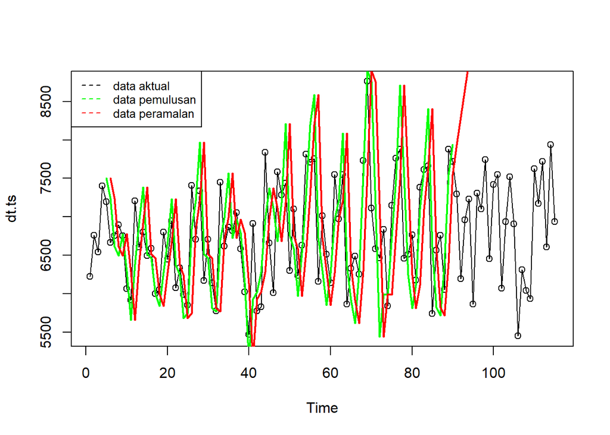

```r
ts.plot(dt.ts)
points(dt.ts)
lines(dma_forecast[,3],col="green",lwd=2)
lines(dma_forecast[,6],col="red",lwd=2)
legend("topleft",c("data aktual","data pemulusan","data peramalan"), lty=8, col=c("black","green","red"), cex=0.8)
```

Terlihat hasil peramalan dari DMA pada akhir periode menunjukan kenaikan yang sangat tinggi, hal ini kemungkinan besar terjadi karena DMA menangkap pola tren yang tidak tersedia di dalam data sehingga DMA kurang cocok digunakan karena data yang digunakan adalah data yang cukup stasioner

#### Evaluasi Model

##### Evaluasi Training

```r
### Training error
dma_train_error <- train.ts - dma_forecast[1:length(train.ts),6]

RMSE_train_dma <- sqrt(mean(dma_train_error^2, na.rm = T))
MAPE_train_dma <- mean(abs(dma_train_error/train.ts)*100, na.rm = T)

RMSE_train_dma
```

```
## [1] 981.1494
```

```r
MAPE_train_dma
```

```
## [1] 10.81436
```

dapat dilihat bahwa nilai error lebih tinggi pada DMA dibanding SMA.

##### Evaluasi Testing

```r
### Testing error
dma_test_error <- test.ts - dma_forecast[length(train.ts)+1:length(test.ts),6]

RMSE_test_dma <- sqrt(mean(dma_test_error^2, na.rm = T))
MAPE_test_dma <- mean(abs(dma_test_error/test.ts)*100, na.rm = T)

RMSE_test_dma
```

```
## [1] 5973.964
```

```r
MAPE_test_dma
```

```
## [1] 79.40849
```

Error yang tinggi juga terlihat karena DMA menangkap pola tren yang tidak tersedia di dalam data.

### Single Expotential Smoothing

#### Forecast SES

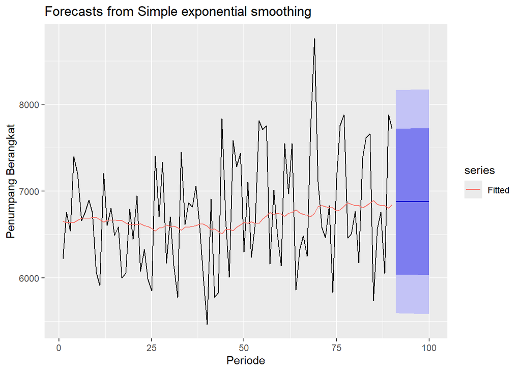

```r
ses1 <- ses(train.ts, beta = FALSE, gamma = FALSE,alpha = NULL)

autoplot(ses1) +
  autolayer(fitted(ses1), series="Fitted") +
  ylab("Penumpang Berangkat") + xlab("Periode")
```

#### Evaluasi Model

##### Evaluasi training

```r
### Training error
ses_train_error <- train.ts - ses1$fitted

RMSE_train_ses <- sqrt(mean(ses_train_error^2, na.rm = T))
MAPE_train_ses <- mean(abs(ses_train_error/train.ts)*100, na.rm = T)

RMSE_train_ses
```

```
## [1] 648.4493
```

```r
MAPE_train_ses
```

```
## [1] 7.797067
```

Nilai error menggunakan SES dengan nilai alpha yang optimal menunjukan model yang memiliki error yang lebih kecil dalam trainining.

##### Evaluasi Testing

```r
### Testing error
ses_prediction <- forecast(ses1, h = 10)
ses_test_error <- test.ts - ses_prediction$mean[1]

RMSE_test_ses <- sqrt(mean(ses_test_error^2, na.rm = T))
MAPE_test_ses <- mean(abs(ses_test_error/test.ts)*100, na.rm = T)

RMSE_test_ses
```

```
## [1] 671.5643
```

```r
MAPE_test_ses
```

```
## [1] 8.565294
```

Hasil pada evaluasi testing lebih tinggi dari training.

### Double Exponential Smoothing

#### Forecast DES

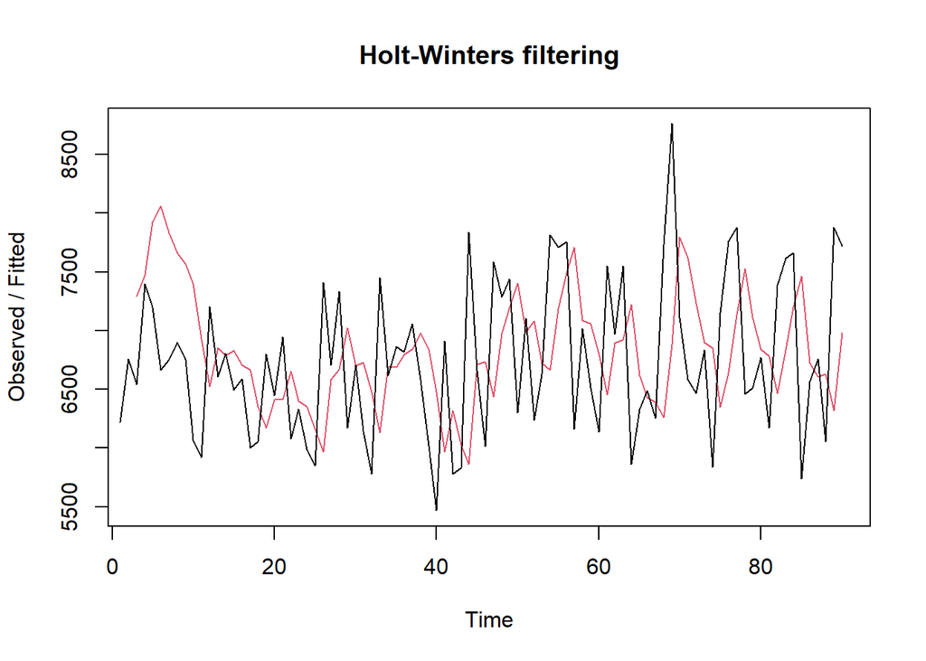

```r
des <- HoltWinters(train.ts, beta = NULL, gamma = FALSE,alpha = NULL)
plot(des)
```

```r
des_predict <- forecast(des, h = 25)
```

#### Evaluasi Model

##### Evaluasi Training

```r
### Training error
des_train_error <- train.ts - des$fitted

RMSE_train_des <- sqrt(mean(des_train_error^2, na.rm = T))
MAPE_train_des <- mean(abs(des_train_error/train.ts)*100, na.rm = T)

RMSE_train_des
```

```
## [1] 3950.014
```

```r
MAPE_train_des
```

```
## [1] 39.35911
```

Sama seperti sebelumnya bahwa model DES menangkap pola tren yang tidak tersedia di data sehingga errornya sangat tinggi.

##### Evaluasi Testing

```r
### Testing error
des_test_error <- test.ts - des_predict$mean[1:25]

RMSE_test_des <- sqrt(mean(des_test_error^2, na.rm = T))
MAPE_test_des <- mean(abs(des_test_error/test.ts)*100, na.rm = T)

RMSE_test_des
```

```
## [1] 1606.571
```

```r
MAPE_test_des
```

```
## [1] 21.05094
```

Nilai error pada testing juga tinggi.

### Holt Winters Smoothing

#### HW Forecasting

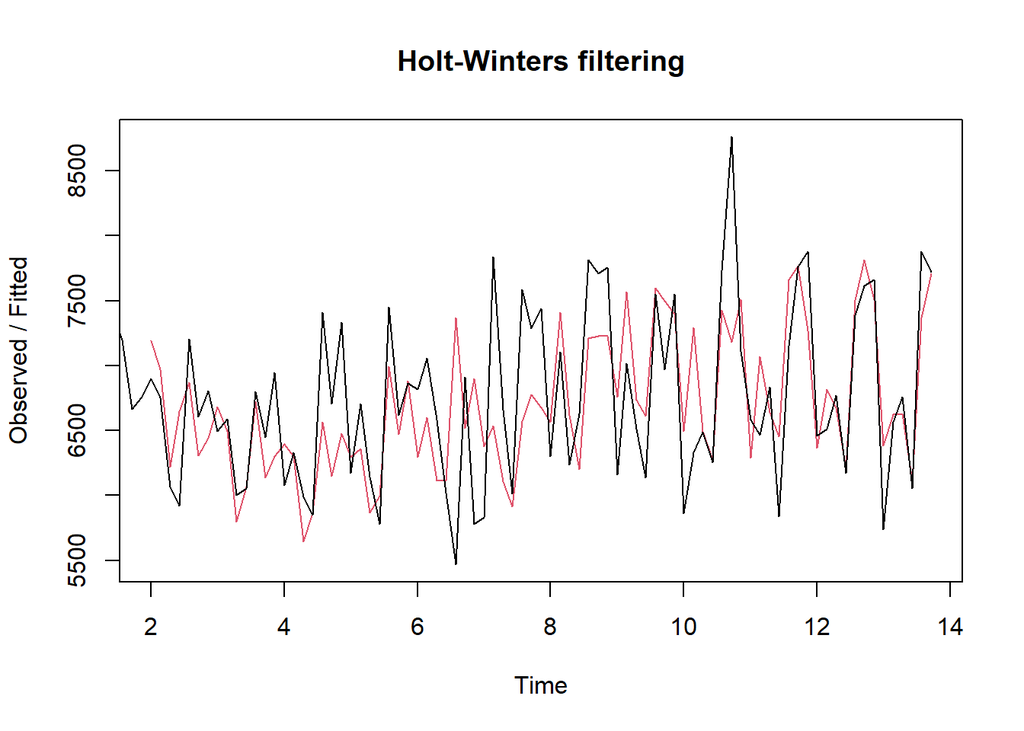

```r
train.winter <- ts(train_dt$penumpang.berangkat, frequency = 7)
hw <- HoltWinters(train.winter, beta = NULL, gamma = NULL,alpha = NULL,seasonal = "additive")
plot(hw)
```

```r
hw_predict <- forecast(hw, h = 25)
```

#### Evaluasi Model

##### Evaluasi Training

```r
### Training error
hw_train_error <- train.winter - hw$fitted

RMSE_train_hw <- sqrt(mean(hw_train_error^2, na.rm = T))
MAPE_train_hw <- mean(abs(hw_train_error/train.winter)*100, na.rm = T)

RMSE_train_hw
```

```
## [1] 4756.01
```

```r
MAPE_train_hw
```

```
## [1] 53.04639
```

Nilai error menggunakan HW karena data yang cenderung stasioner juga.

##### Evaluasi Testing

```r
### Testing error
hw_test_error <- test.ts - hw_predict$mean[1:25]

RMSE_test_hw <- sqrt(mean(hw_test_error^2, na.rm = T))
MAPE_test_hw <- mean(abs(hw_test_error/test.ts)*100, na.rm = T)

RMSE_test_hw
```

```
## [1] 515.1675
```

```r
MAPE_test_hw
```

```
## [1] 6.135798
```

Walaupun nilai error pada training cukup tinggi, namun nilai error model HW yang mampu menghasilkan prediksi yang lebih baik diantara semua model yang ada. Hal ini kemugnkinan besar karena penentuan nilai alpha, beta, dan gamma secara optimum.

```r
hw
```

```
## Holt-Winters exponential smoothing with trend and additive seasonal component.
##
## Call:
## HoltWinters(x = train.winter, alpha = NULL, beta = NULL, gamma = NULL,     seasonal = "additive")
##
## Smoothing parameters:
##  alpha: 0.09213134
##  beta : 0.1241054
##  gamma: 0.3684538
##
## Coefficients:
##             [,1]
## a  6734.50413345
## b    -0.09172007
## s1  804.84632511
## s2 -600.78665199
## s3  -99.43479867
## s4  -18.32244535
## s5 -607.64180135
## s6  851.48314117
## s7  979.74147193
```

nilai parameter gamma adalah yang paling besar, sehingga kemungkinan besar pola musiman yang lebih dapat menjelaskan data yang ada.